# Homework3

Huseyin Sengun - IE360 - Spring 2021

1. INTRODUCTION

In this study, we will be trying to understand and predict the tomorrow’s hourly electricity consumption of Turkey. The consumption series are made publicly available by EPİAŞ.

The aim of the report is to understand the properties of the electricity consumption data to build and compare alternative forecasting approaches. Daily consumption series is not stationary due to several reasons. In this task, we will be devising approaches to transform the series to obtain new series that is as stationary as possible.

The hourly data we are working on is between 01.01.2016 and 20.05.2021. With some analyses, Autoregressive (AR) and Moving Average (MA) models will be established and then, the most appropriate ARMA model will be chosen. Then, by comparing forecasts with actual data, we will calculate the error terms.

2. PREPARING DATA AND SOME MANIPULATION

Loading necessary libraries:

```r
library(knitr)
library(ggplot2)
library(lubridate)
library(data.table)
library(dplyr)
library(forecast)
library(urca)
```

2.1 Reading the Data

```r
econsumption <- read.csv("GercekZamanliTuketim-01012016-20052021.csv")
econsumption <- data.table(econsumption)
str(econsumption)
```

```
## Classes 'data.table' and 'data.frame':   47208 obs. of  3 variables:
##  $ Tarih                : chr  "01.01.2016" "01.01.2016" "01.01.2016" "01.01.2016" ...
##  $ Saat                 : chr  "00:00" "01:00" "02:00" "03:00" ...
##  $ Tüketim.Miktarı..MWh.: chr  "26.277,24" "24.991,82" "23.532,61" "22.464,78" ...
##  - attr(*, ".internal.selfref")=<externalptr>
```

The hourly data is between 01 Jan 2016 and 20 May 2021. There are 47208 observations and three columns.

2.2 Data Manipulation

```r
names(econsumption) <- c("Date", "Hour", "Consumption")
econsumption$Date <- as.Date(econsumption$Date, format = "%d.%m.%Y")
econsumption$Hour <- rep(seq(0,23, by=1), times = nrow(econsumption)/24)
econsumption[,Consumption:=gsub('\\.', '', Consumption)]
econsumption[,Consumption:=gsub('\\,', '.', Consumption)]
econsumption[,Consumption:=as.numeric(Consumption)]
head(econsumption)
```

```
##          Date Hour Consumption
## 1: 2016-01-01    0    26277.24
## 2: 2016-01-01    1    24991.82
## 3: 2016-01-01    2    23532.61
## 4: 2016-01-01    3    22464.78
## 5: 2016-01-01    4    22002.91
## 6: 2016-01-01    5    21957.08
```

After some manipulation We have our data almost ready. To better understand the data, it would be good to visualize it. The below plots show first looks about the data:

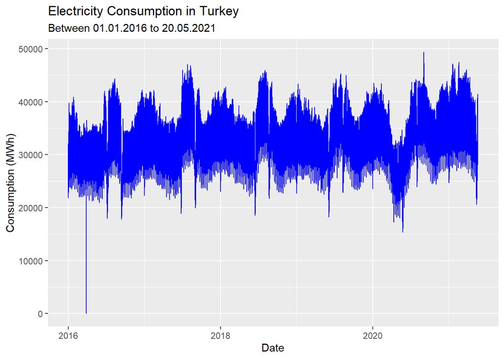

```r
ggplot(data=econsumption, aes(x=Date,y=Consumption))+geom_line(col="blue"
)+labs(x="Date",y="Consumption (MWh)",title="Electricity Consumption in Turkey", subtitle="Between 01.01.2016 to 20.05.2021")
```

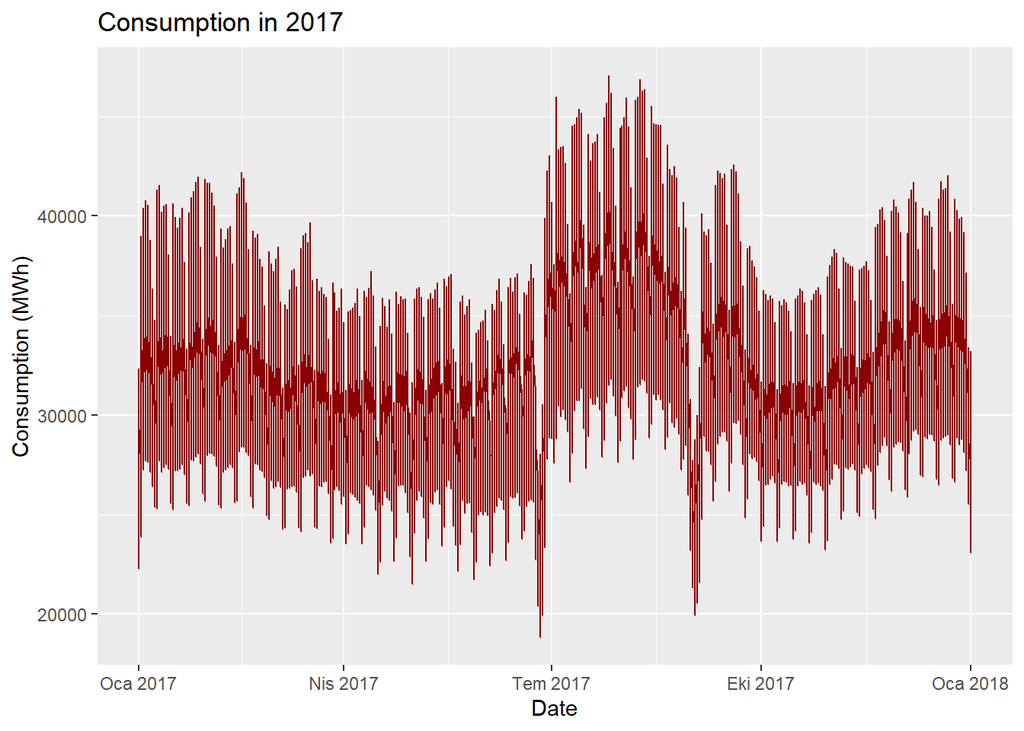

```r
econsumption2017 <- (ggplot(data=econsumption[econsumption$Date>="2017-01-01"&econsumption$Date<="2018-01-01"], aes(x=Date,y=Consumption))+geom_line(col="dark red")
  +labs(x="Date",y="Consumption (MWh)",title="Consumption in 2017 ")
)
econsumption2017
```

With the two plots above, we can conclude some seasonalities and patterns. The second plot indicates that the electricity consumption increases during the summer months. Also, there could be seen a somehow decrease during the autumn and spring. There are 2 sharp declines in the electricity consumption which are because of the religious holidays. Also, in the second graph the weekend effect could be seen.

By looking the first plot, there is a slight increasing trend with the development of the industrial activities and the population.

There is a sharp decrease at the end of the first quarter of 2020 which is about the Covid19 lockdowns and slower industrial activities.

Finally, the lowest consumption is on 27 March 2016. After searching for the day, I conclude that it’s not a special day and the consumption data at this day is wrong due to some technical errors with the EPİAŞ, I think.